# Hierarhical Models with Binary Latent Variable

### Diffusion Process

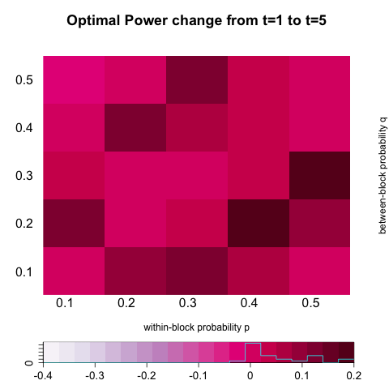

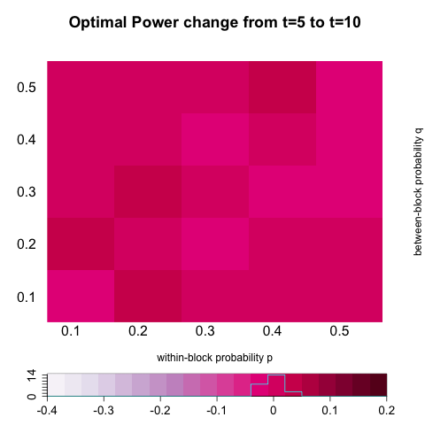

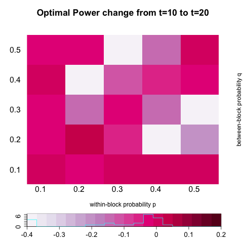

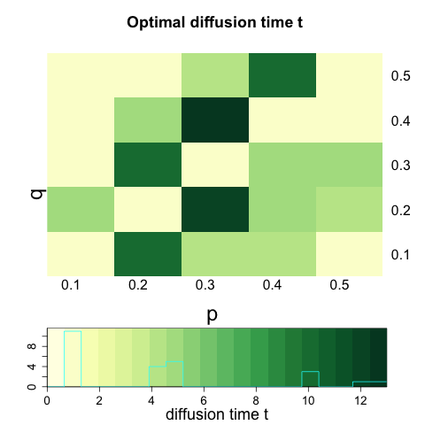

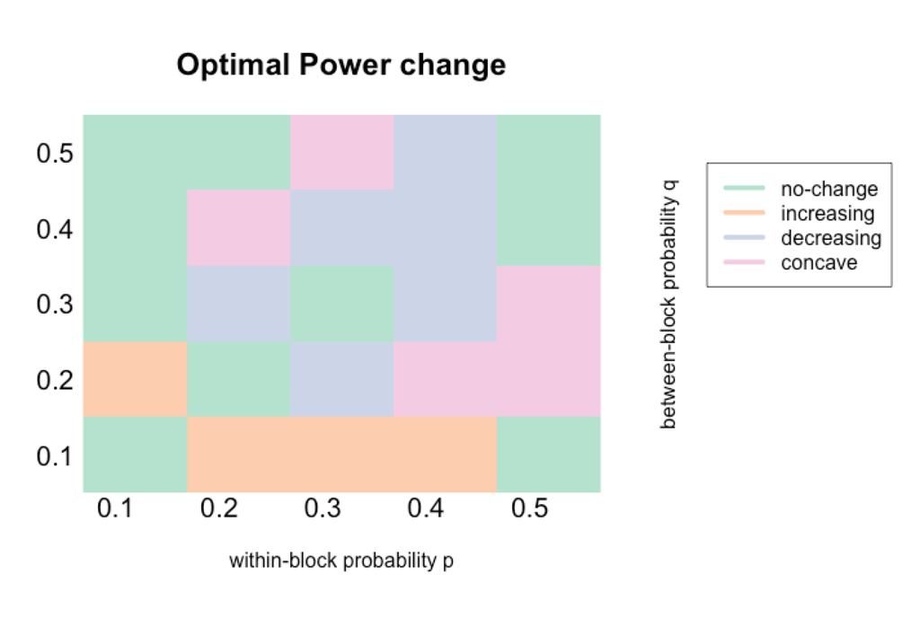

### One within-block probability p vs. Others r

It is also plausible that probability of having edges differs for only one block and for other parts they are the same.

$X \sim Bern(0.5)$

$Z \sim \left\{ \begin{array}{cc} Bern(0.6) & X = 0 \\ Bern(0.4) & X = 1 \end{array} \right.$

$A \sim Bern \left[ \begin{array}{cc} \color{red}{p} & \color{blue}{r} \\ \color{blue}{r} & \color{blue}{r} \end{array} \right]$

### Optimal power

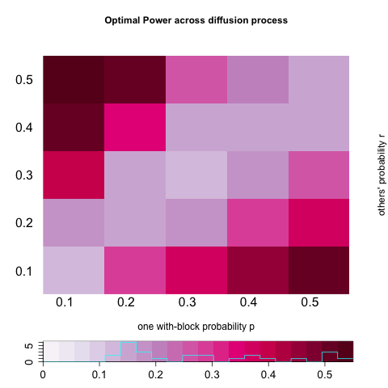

### Discrepancy between local and global scale

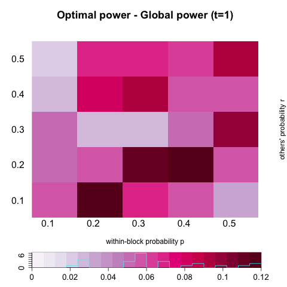

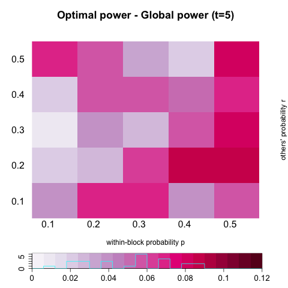

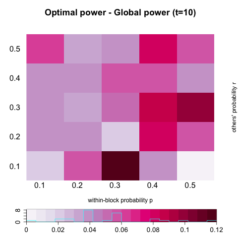

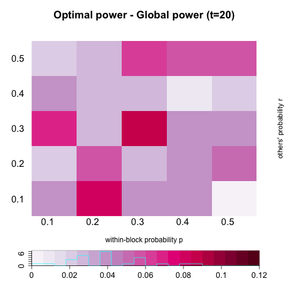

### Diffusion Process

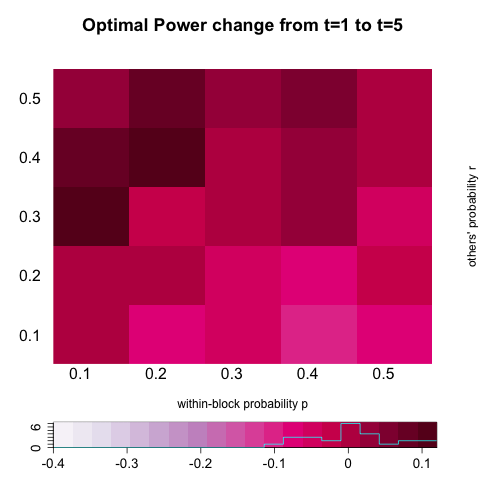

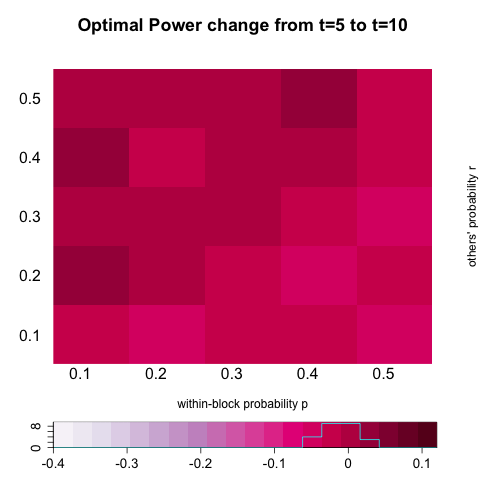

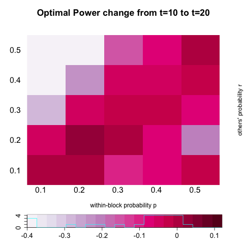

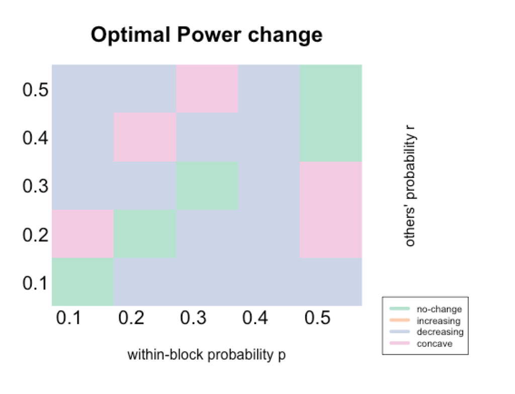

$X \sim Bern(0.5)$

$Z \sim \left\{ \begin{array}{cc} Bern(0.6) & X = 0 \\ Bern(0.4) & X = 1 \end{array} \right.$

$A \sim Bern \left[ \begin{array}{cc} \color{red}{p} & r \\ r & \color{blue}{q} \end{array} \right]$

### q = p + 0.1

### Optimal power

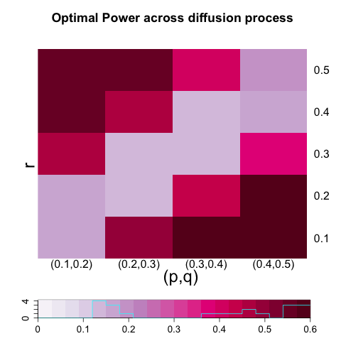

### Discrepancy between local and global scale

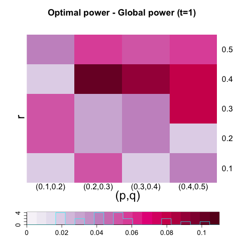

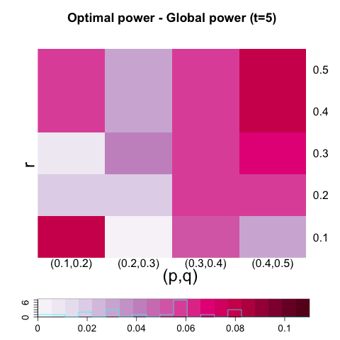

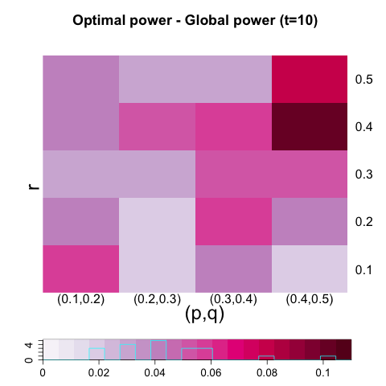

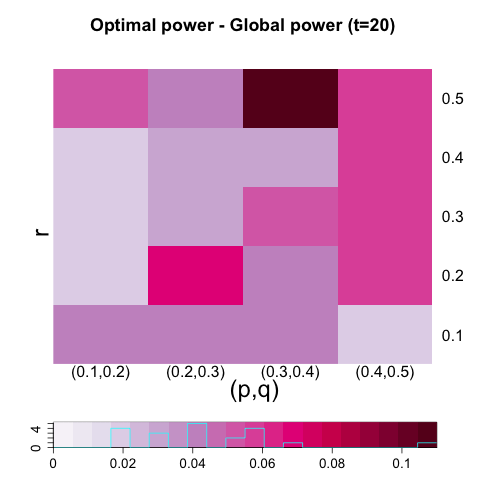

### Diffusion Process

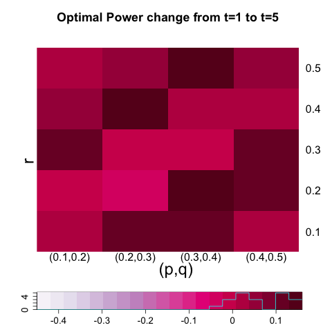

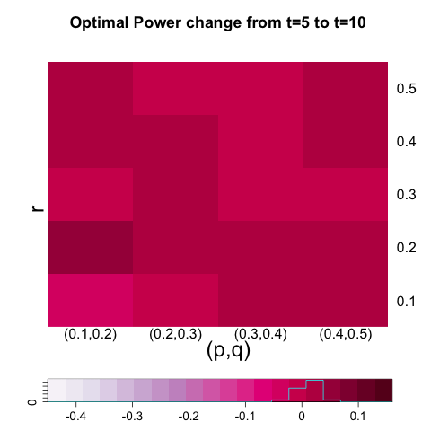

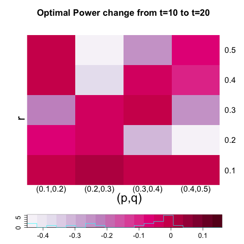

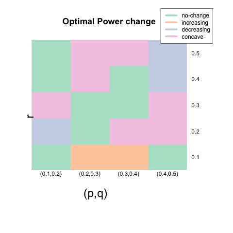